# Дипломный проект

### На тему:"Автоматизация бизнес-процесса (автоматизация учета заявок) ООО <<Мегаполис>>"

### Обучающийся: Власов Василий Евгеньевич

### Руководитель: Цой Валентин Валерьевич

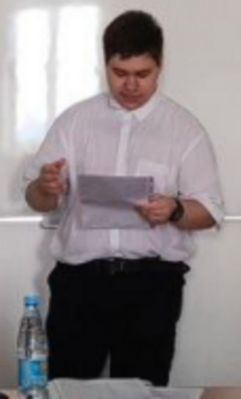

Честно, спросить человека даже не успел...

# Дипломный проект на тему "Автоматизация взаимоотношений с клиентами на примере предприятия "АС-Инвест""

### Обучающийся: Выдряков Игорь Владимирович

### Руководитель: *

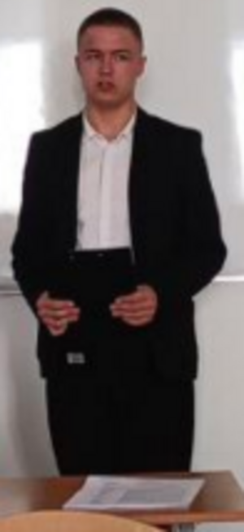

Что подразумевается под Аатоматизацией?

Ответ: Использовал JavaScript без библиотек...

На вопросы других участником ГЕК отвечал приемлимо бодро!

# Дипломный Проект На тему "Автоматизация учета услуг на примере ООО "Кардан-Гарант Групп""

### Обучающийся: Гусев Илья Александрович

### Руководитель: Алексахина Светлана Александровна

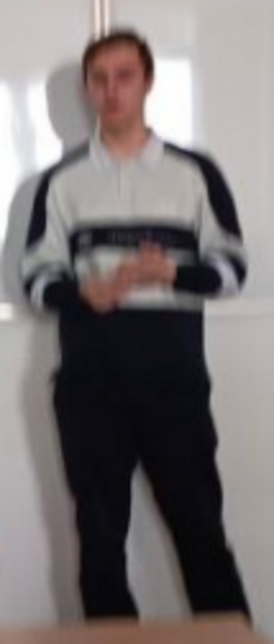

- База данных через что создавалась?
  - "Через Prisma"
  - (https://www.prisma.io/)
- Интерфейс WEB или Desktop
  - "WEB"
- (Дальнейшие вопросы задавались после того как испытуемый отказался создавать переменную в javascript на листе бумеги)
- javascript явно типизированный или неявнотипизированный?
  - Неявнотипизированный
- javascript интерпретатор или компилятор
  - Интерпритатор
- Прототипирование в javascript
  - Для ускорения разработки
  - (Вопрос задавался не про это, в языке есть отдельный термин)
- Наследование
  - Затрудняюсь ответить
  - (Вывод javascript "--")

# Дипломный проект на тему «Автоматизация бизнес-процесса доставки на примере ООО «ФБ ИНВЕсТ»

### Обучающийся: Куренной Кирилл Александрович

### Руководитель: Солдатова Ольга Борисовна

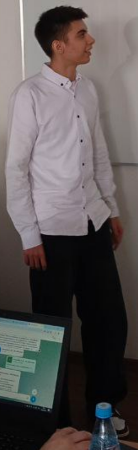

- CSS?
  - Использовал
- SQL ?
  - Hibernate
  - SQL тоже использовал, но hibernate понравился больше... Он может...
  - (😭😭😭) (сойдет)
- Как создавалась база данных
  - Создавалась база данных мышкой....

В принципе все рассказал.

Написание на чистом SQL базы данных считается хорошим стилем. Можно в принципе создавать через менеджер администрирования сервера баз данных "Мышкой". Это считается уже не так пристижно. Можно испольсовать "полуфабрикат" через менеджер управления сущьностями "Hibernate", где на вход подаются классы, на выходе получаем базы данных, адаптеры данных, и автогенерируемые SQL запросы. Такой вариант не позволяет продемонстрировать навыки SQL, и применим для конвеерной промышленной разработки в целях экономии времени. В таком варианте крайне высок шанс новичку "напортачить".

Испытуемый создавал базу данных через менеджеры администрирования сервера баз данных "Мышкой". SQL запросы не писал, вместо этого, так сказать, заварил лапшу кипятком через менеджер управления сущьностями "Hibernate".

Шатко, но вполне можно

# Дипломный проект «Автоматизация управления проектами на примере АО «Файненшеп Сервисес Текнолоджис»

### Обучающийся: Гуторов Даниил Сергеевич

### Руководитель: Солдатова Ольга Борисовна

Отправка документов под цифровой подписью отправляется на сервер открывается процесс на чтение документа ворд через process . start документ не отслеживается, но проверяется на достоверность директором, (интегрированным в сервер) видит и хранится в БД байткодом до 4 килобайт есть шаблон ворд документоотчета.

(Мутная история)

# Дипломный проект на тему Автоматизация анализа продажтоваров "Алтеки...

### Обучающийся: Амаров Микаил Раджабович

### Руководитель: Скопин Владимир Игоревич

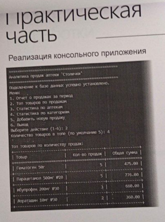

- Ответы Питон использовал, потому что так сложилось
- ....
- Использовался PostgreSQL потому что люблю =)

(то что приложение было консольное - было очень странно)

# Дипломный проект на тему «Автоматизация процесса приёма пациентов на базе организации Premier Medlca»

### Обучающийся: Малышкин Сергей Петрович

### Руководитель: Жданцев Кирилл Николаевич

- Ответ. VBA это ассемблер и язык программирования Microsoft Access
- (это финиш)

# Дипломный проект на тему Автоматизация взаимоотношений с клнентами на примере предприятия гостиницы «Аврора Балашиха»

### Обучающийся: Семичев Никитв Александрович

### Руководитель: Гринева Елизавета Сергеевна

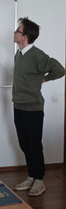

- Почему не PostgreSQL?
  - мне нравится SQLite
- Как происходило создание базы даных на Python SQLite?
  - не помню
- Есть ли закальцованность в базе данных и ли просто криво нарисовано?
  - Криво нарисовано

# Дипломный проект на тему «АВТОМАТИЗАЦИЯ ... ПРОДАЖ ТОВАРОВ...

### Обучающийся: Фёдоров Егор Антонович

### Руководитель: Сибирев Иван Валерьевич

Вопросов не задавал.

# Дипломный Проект Автоматизация управления проектами на примере «Эргостол».

### Обучающийся: Хакназаров Парвиз Киромиддинович

### Руховодитель: Горшкова Анастасия Анатольевна

[figure not shown]

sqlite python мне нравится но я не помню как на нем работал

# Дипломный проект натему «Разработка сайта для регистрации и учет заказов на примере ООО "Движение"»

### Обучающийся: Черсков Алексей Владимирович

### Руководитель: Жданцев Кирилл Николаевич

- Повему не PostgreSQL
- Потому что на PostgreSQL легко перейти, но мнелегче sqlite